### Kaggle Competition:

#### Carvana: Don’t Get Kicked

Carvana hosted a Kaggle competition wherein competitors took data about US market automobiles at used car auctions in an attempt to determine whether the car was a “Good Buy” or a “Bad Buy” for the purchaser. Information about the challenge can be found on the Kaggle website at https://www.kaggle.com/c/DontGetKicked.

Used car auctions provide a means for automotive dealerships to replenish their inventory of used cars to sell. However, buying used cars, regardless of venue or intent, is never without risk. In an effort to minimize this risk, automotive resellers must look at a number of different factors before they purchase a vehicle in order to maximize the returns on their investment. Having to deal with issues such as major undisclosed needed repairs, odometer discrepancies, titling complications, etc., greatly increases the total cost incurred by dealers for each car, so being able to identify these types of vehicles in advance would be very beneficial to their process.

### Data Loading

#### Loading necessary R packages

```r
require(tidyverse)
require(caret)
require(lubridate)
require(mice)
require(naniar)
require(DMwR)
require(pROC)
require(xgboost)
require(randomForest)
require(e1071)
require(corrplot)
require(JOUSBoost)
```

#### Reading in the data and temporarily combining the datasets to facilitate data cleaning

```r
wd <- "C:/Users/Bryan/Google Drive/Kaggle/Carvana/"
train.set <- read.csv(paste(wd, "training.csv", sep = ""), stringsAsFactors = FALSE)
test.set <- read.csv(paste(wd, "test.csv", sep = ""), stringsAsFactors = FALSE)
test.set <- test.set %>% mutate(set = "test",
                                IsBadBuy = NA)
train.set <- train.set %>% mutate(set = "train")
data.set <- rbind(train.set, test.set)
rm(train.set); rm(test.set)
```

### Inspecting the Data

The data isn’t especially troublesome, but it is apparent that there is much that can be done to improve its overall structure.

#### Examining the structure of the dataset

Even with a cursory look at the data, it’s apparent that there is a significant amount of data that can extracted and cleaned from a handful of fields.

```r
summary(data.set)
```

```
##      RefId           IsBadBuy      PurchDate           Auction
##  Min.   :     1   Min.   :0.00    Length:121690      Length:121690
##  1st Qu.: 30443   1st Qu.:0.00    Class :character   Class :character
##  Median : 60874   Median :0.00    Mode  :character   Mode  :character
##  Mean   : 60874   Mean   :0.12
##  3rd Qu.: 91307   3rd Qu.:0.00
##  Max.   :121746   Max.   :1.00
##                   NA's   :48707
##     VehYear       VehicleAge        Make              Model
##  Min.   :2001   Min.   :0.000   Length:121690      Length:121690
##  1st Qu.:2004   1st Qu.:3.000   Class :character   Class :character
##  Median :2005   Median :4.000   Mode  :character   Mode  :character
##  Mean   :2005   Mean   :4.192
##  3rd Qu.:2007   3rd Qu.:5.000
##  Max.   :2010   Max.   :9.000
##
##      Trim             SubModel            Color
##  Length:121690      Length:121690      Length:121690
##  Class :character   Class :character   Class :character
##  Mode  :character   Mode  :character   Mode  :character
##
##
##
##
##  Transmission       WheelTypeID         WheelType             VehOdo
##  Length:121690      Length:121690      Length:121690      Min.   :   223
##  Class :character   Class :character   Class :character   1st Qu.: 61990
##  Mode  :character   Mode  :character   Mode  :character   Median : 73379
##                                                           Mean   : 71531
##                                                           3rd Qu.: 82429
##                                                           Max.   :115717
##
##  Nationality            Size           TopThreeAmericanName
##  Length:121690      Length:121690      Length:121690
##  Class :character   Class :character   Class :character
##  Mode  :character   Mode  :character   Mode  :character
##
##
##
##
```

[output cut: 41 more lines]

```
##  Length:121690      Min.   :    1   Min.   :0.00000   Min.   : 462
##  Class :character   1st Qu.: 5450   1st Qu.:0.00000   1st Qu.: 853
##  Mode  :character   Median : 6720   Median :0.00000   Median :1169
##                     Mean   : 6743   Mean   :0.02397   Mean   :1278
##                     3rd Qu.: 7910   3rd Qu.:0.00000   3rd Qu.:1623
##                     Max.   :56950   Max.   :1.00000   Max.   :7498
##
##      set
##  Length:121690
##  Class :character
##  Mode  :character
##
##
##
##
```

### Data Cleaning and Processing

The focus of this stage will be on processing several fields to get a number of new features and preparing several factor fields for means encoding.

#### Renaming a misspelled predictor name

```r
names(data.set)[which(names(data.set) == "MMRAcquisitonRetailCleanPrice")] <- "MMRAcquisitionRetailCleanPrice"
```

#### Creating new predictors based on date of vehicle purchase

Date information can be very useful not only in providing an absolute measure of time, but also in generating factor variables that indirectly contribute to a model’s predictive ability by uncovering hidden structures within the auction system that isn’t represented elsewhere in the data. As a simple example, if a specific auction takes place on Tuesdays and Fridays every week, but Fridays auctions only include cars that were not sold on Tuesdays and don’t include any new acquisitions, then that could be potentially useful to know.

```r
data.set <- data.set %>% mutate(PurchDate = mdy(PurchDate)) %>%
                         mutate(YearPurchased = year(PurchDate),
                                MonthPurchased = month(PurchDate),
                                DayPurchased = day(PurchDate)) %>%
                         mutate(DayofWeekPurchased = as.factor(weekdays(PurchDate)),
                                AdjDaysSincePurchase = as.numeric(max(PurchDate) - PurchDate)) %>%
                         mutate(YearPurchased = as.factor(YearPurchased),
                                MonthPurchased = as.factor(MonthPurchased),
                                DayPurchased = as.factor(DayPurchased))
```

#### Comparing Vehicle Age to Vehicle Year

Initially, it would seem that these two fields would represent the exact same information. However, the Vehicle Year does not always correspond to the year that the vehicle was actually purchased. 2020 model year cars are often available for sale in 2019, for example, and the data bears that out.

```r
table(data.set$VehicleAge, data.set$VehYear)
```

```
##
##      2001  2002  2003  2004  2005  2006  2007  2008  2009  2010
##   0     0     0     0     0     0     0     0     0     1     9
##   1     0     0     0     0     0     0     0  3286  1312     0
##   2     0     0     0     0     0     0  6627  7764     0     0
##   3     0     0     0     0     0 13547 13082     0     0     0
##   4     0     0     0     0 13527 14821     0     0     0     0
##   5     0     0     0  9455 12134     0     0     0     0     0
##   6     0     0  5857  7462     0     0     0     0     0     0
##   7     0  3362  4532     0     0     0     0     0     0     0
##   8  1440  2381     0     0     0     0     0     0     0     0
##   9  1091     0     0     0     0     0     0     0     0     0
```

#### Examining categorical predictor related to which auction the vehicle was purchased from

```r
table(data.set$Auction)
```

```
##
##   ADESA MANHEIM   OTHER
##   27433   68779   25478
```

```r
data.set$Auction <- as.factor(data.set$Auction)
```

#### Examining and correcting vehicle make information as needed

The beginning of the data cleaning/normalization process.

```r
data.set$Make <- as.factor(data.set$Make)
table(data.set$Make)
```

```
##
##        ACURA        BUICK     CADILLAC    CHEVROLET     CHRYSLER
##           59         1220           62        28734        14894
##        DODGE         FORD          GMC        HONDA       HUMMER
##        21007        18746         1037          815            1
##      HYUNDAI     INFINITI        ISUZU         JEEP          KIA
##         3122           70          219         2831         4398
##        LEXUS      LINCOLN        MAZDA      MERCURY         MINI
##           50          163         1683         1533           34
##   MITSUBISHI       NISSAN   OLDSMOBILE     PLYMOUTH      PONTIAC
##         1813         3313          406            2         7259
##       SATURN        SCION       SUBARU       SUZUKI       TOYOTA
##         3555          214           40         2201         1924
## TOYOTA SCION   VOLKSWAGEN        VOLVO
##            1          205           79
```

```r
data.set$Make[data.set$Make == "PLYMOUTH"] <- "DODGE"
data.set$Make[data.set$Make == "TOYOTA SCION"] <- "SCION"
data.set$Make[data.set$Make == "HUMMER"] <- "GMC"
```

#### Generating new predictor variables based on model information.

This serves two purposes; it separates potentially important data into multiple predictors and it allows for reduction in overall number of vehicle model levels. From this process, the data will now include predictors regarding each car’s drive system (4WD, AWD, 2WD), its number of cylinders (4, 6, 8), the drive wheels (Front, Rear, All), it’s engine size (measured by liters of displacement) and whether it’s a hybrid or not.

```r
data.set <- data.set %>% mutate(DriveType = case_when(grepl("AWD", Model) == TRUE ~ "AWD",
                                                      grepl("4WD", Model) == TRUE ~ "4WD",
                                                      grepl("AWD|4WD", Model) == FALSE ~ "2WD"),
                                NumCyls = case_when(grepl("V8|8C|V-8|V 8", Model) == TRUE ~ 8,
                                                    grepl("V6|I6|6C|V-6|I-6|V 6|I 6", Model) == TRUE ~ 6,
                                                    grepl("I4|4C|I-4|I 4", Model) == TRUE ~ 4,
                                                    grepl("V8|V6|I6|I4|8C|6C|4C|V-8|V-6|I-4|I 4|V 8|V 6|I 6", Model) == FALSE ~ 0)) %>%
                        mutate(DriveWheels = case_when(grepl("FWD", Model) == TRUE ~ "Front",
                                                       grepl("RWD", Model) == TRUE ~ "Rear",
                                                       grepl("AWD", Model) == TRUE ~ "All"),
                               Model = gsub(" AWD| 4WD| 2WD| V8| V6| I6| I4| RWD| FWD| 8C| 6C| 4C| PICKUP| V-8| V-6", "", Model)) %>%
                        mutate(Model = gsub(" I-4| I-6| I 6| I 4| V 6| V 8| PICKU| PIC", "", Model)) %>%
                        mutate(LitersDisp = as.numeric(str_extract(Model, "[0-9]\\.[0.9]"))) %>%
                        mutate(Model = gsub(" [0-9]\\.[0-9]L| EFI| MPI| SPI| MFI| SFI|[[:punct:]]", "", Model)) %>%
                        mutate(Model = trimws(gsub("HYBRID", "", Model)))
```

#### Normalizing entries for vehicle model data

```r
data.set$Model <- gsub("1500.*SIERRA.*", "1500 SIERRA", data.set$Model)
data.set$Model <- gsub("1500.*SILVERADO.*", "1500 SILVERADO", data.set$Model)
data.set$Model <- gsub("2500.*SILVERADO.*", "2500 SILVERADO", data.set$Model)
data.set$Model <- gsub("300.*", "300", data.set$Model)
data.set$Model <- gsub("32 CL.*", "32 CL", data.set$Model)
data.set$Model <- gsub("32 TL.*", "32 TL", data.set$Model)
data.set$Model <- gsub("350Z.*", "350Z", data.set$Model)
data.set$Model <- gsub("626.*", "626", data.set$Model)
data.set$Model <- gsub("ACCORD.*", "ACCORD", data.set$Model)
data.set$Model <- gsub("AERIO.*", "AERIO", data.set$Model)
data.set$Model <- gsub("ALERO.*", "ALERO", data.set$Model)
data.set$Model <- gsub("ALTIMA.*", "ALTIMA", data.set$Model)
data.set$Model <- gsub("ARMADA.*", "ARMADA", data.set$Model)
data.set$Model <- gsub("AVALON.*", "AVALON", data.set$Model)
data.set$Model <- gsub("AVENGER.*", "AVENGER", data.set$Model)
data.set$Model <- gsub("AVEO.*", "AVEO", data.set$Model)
data.set$Model <- gsub("BONNEVILLE.*", "BONNEVILLE", data.set$Model)
data.set$Model <- gsub("CAMARO.*", "CAMARO", data.set$Model)
data.set$Model <- gsub("CAMRY.*SOLARA.*", "SOLARO", data.set$Model)
data.set$Model <- gsub("CAMRY.*", "CAMRY", data.set$Model)
data.set$Model <- gsub("CARAVAN SE.*", "CARAVAN", data.set$Model)
data.set$Model <- gsub("CANYON.*", "CANYON", data.set$Model)
data.set$Model <- gsub("CENTURY.*", "CENTURY", data.set$Model)
data.set$Model <- gsub("CHARGER.*", "CHARGER", data.set$Model)
data.set$Model <- gsub("CIVIC.*", "CIVIC", data.set$Model)
data.set$Model <- gsub("COMMANDER.*", "COMMANDER", data.set$Model)
data.set$Model <- gsub("CENTURY.*", "CENTURY", data.set$Model)
data.set$Model <- gsub("COOPER.*", "COOPER", data.set$Model)
data.set$Model <- gsub("COROLLA.*", "COROLLA", data.set$Model)
data.set$Model <- gsub("COUPE.*", "COUPE", data.set$Model)
data.set$Model <- gsub("CRV.*", "CRV", data.set$Model)
data.set$Model <- gsub("DURANGO.*", "DURANGO", data.set$Model)
data.set$Model <- gsub("ECHO.*", "ECHO", data.set$Model)
data.set$Model <- gsub("ECLIPSE.*", "ECLIPSE", data.set$Model)
data.set$Model <- gsub("ENVOY.*", "ENVOY", data.set$Model)
data.set$Model <- gsub("ES300.*", "ES300", data.set$Model)
data.set$Model <- gsub("ESCAPE.*", "ESCAPE", data.set$Model)
data.set$Model <- gsub("ESCORT.*", "ESCORT", data.set$Model)
data.set$Model <- gsub("EXCURSION.*", "EXCURSION", data.set$Model)
data.set$Model <- gsub("EXPEDITION.*", "EXPEDITION", data.set$Model)
data.set$Model <- gsub("F150.*", "F150", data.set$Model)
data.set$Model <- gsub("F250.*", "F250", data.set$Model)
data.set$Model <- gsub("FOCUS.*", "FOCUS", data.set$Model)
data.set$Model <- gsub("FORENZA.*", "FORENZA", data.set$Model)
data.set$Model <- gsub("FREESTYLE.*", "FREESTYLE", data.set$Model)
data.set$Model <- gsub("FUSION.*", "FUSION", data.set$Model)
data.set$Model <- gsub("G35.*", "G35", data.set$Model)
data.set$Model <- gsub("GALANT.*", "GALANT", data.set$Model)
data.set$Model <- gsub("GRAND AM.*", "GRAND AM", data.set$Model)
data.set$Model <- gsub("GRAND CHEROKEE.*", "GRAND CHEROKEE", data.set$Model)
data.set$Model <- gsub("GRAND MARQUIS.*", "GRAND MARQUIS", data.set$Model)
data.set$Model <- gsub("GRAND PRIX.*", "GRAND PRIX", data.set$Model)
data.set$Model <- gsub("GRAND VITARA.*", "GRAND VITARA", data.set$Model)
data.set$Model <- gsub("HHR.*", "HHR", data.set$Model)
data.set$Model <- gsub("HIGHLANDER.*", "HIGHLANDER", data.set$Model)
data.set$Model <- gsub("I30.*", "I30", data.set$Model)
data.set$Model <- gsub("I35.*", "I35", data.set$Model)
data.set$Model <- gsub("IMPALA.*", "IMPALA", data.set$Model)
data.set$Model <- gsub("ION.*", "ION", data.set$Model)
data.set$Model <- gsub("JETTA.*", "JETTA", data.set$Model)
data.set$Model <- gsub("L SERIES.*", "L SERIES", data.set$Model)
data.set$Model <- gsub("LE SABRE.*", "LE SABRE", data.set$Model)
data.set$Model <- gsub("^LS *", "LS", data.set$Model)
data.set$Model <- gsub("LS DO", "LS", data.set$Model)
data.set$Model <- gsub("LUCERNE.*", "LUCERNE", data.set$Model)
data.set$Model <- gsub("M45.*", "M45", data.set$Model)
data.set$Model <- gsub("MAGNUM.*", "MAGNUM", data.set$Model)
data.set$Model <- gsub("MALIBU.*", "MALIBU", data.set$Model)
data.set$Model <- gsub("MATRIX.*", "MATRIX", data.set$Model)
data.set$Model <- gsub("MAXIMA.*", "MAXIMA", data.set$Model)
data.set$Model <- gsub("MAZDA6.*", "MAZDA6", data.set$Model)
data.set$Model <- gsub("MDX.*", "MDX", data.set$Model)
data.set$Model <- gsub("MIATA.*", "MIATA", data.set$Model)
data.set$Model <- gsub("MONTANA.*", "MONTANA", data.set$Model)
data.set$Model <- gsub("MPV.*", "MPV", data.set$Model)
data.set$Model <- gsub("MOUNTAINEER.*", "MOUNTAINEER", data.set$Model)
data.set$Model <- gsub("MURANO.*", "MURANO", data.set$Model)
data.set$Model <- gsub("MUSTANG.*", "MUSTANG", data.set$Model)
data.set$Model <- gsub("NAVIGATOR.*", "NAVIGATOR", data.set$Model)
data.set$Model <- gsub("NEON.*", "NEON", data.set$Model)
data.set$Model <- gsub("OPTIMA.*", "OPTIMA", data.set$Model)
data.set$Model <- gsub("OUTLANDER.*", "OUTLANDER", data.set$Model)
data.set$Model <- gsub("PACIFICA.*", "PACIFICA", data.set$Model, ignore.case = TRUE)
data.set$Model <- gsub("PATHFINDER.*", "PATHFINDER", data.set$Model)
data.set$Model <- gsub("PILOT.*", "PILOT", data.set$Model)
data.set$Model <- gsub("PRIUS.*", "PRIUS", data.set$Model)
data.set$Model <- gsub("PRIZM.*", "PRIZM", data.set$Model)
data.set$Model <- gsub("PROTEGE 5.*", "PROTEGE 5", data.set$Model)
data.set$Model <- gsub("PT CRUISER.*", "PT CRUISER", data.set$Model)
data.set$Model <- gsub("QX4.*", "QX4", data.set$Model)
data.set$Model <- gsub("RAIDER.*", "RAIDER", data.set$Model)
data.set$Model <- gsub("RAV4.*", "RAV4", data.set$Model)
data.set$Model <- gsub("RENO.*", "RENO", data.set$Model)
data.set$Model <- gsub("RIO.*", "RIO", data.set$Model)
data.set$Model <- gsub("RONDO.*", "RONDO", data.set$Model)
data.set$Model <- gsub("RX300.*", "RX300", data.set$Model)
data.set$Model <- gsub("S SERIES.*", "S SERIES", data.set$Model)
data.set$Model <- gsub("S10.*", "S10", data.set$Model)
data.set$Model <- gsub("SABLE.*", "SABLE", data.set$Model)
data.set$Model <- gsub("SANTA FE.*", "SANTA FE", data.set$Model)
data.set$Model <- gsub("SEBRING.*", "SEBRING", data.set$Model)
data.set$Model <- gsub("SENTRA.*", "SENTRA", data.set$Model)
data.set$Model <- gsub("SIENNA.*", "SIENNA", data.set$Model)
data.set$Model <- gsub("SIERRA.*1500.*", "1500 SIERRA", data.set$Model)
data.set$Model <- gsub("SILHOUETTE.*", "SILHOUETTE", data.set$Model)
data.set$Model <- gsub("SONATA.*", "SONATA", data.set$Model)
data.set$Model <- gsub("SPECTRA.*", "SPECTRA", data.set$Model)
data.set$Model <- gsub("SPORTAGE.*", "SPORTAGE", data.set$Model)
data.set$Model <- gsub("SRX.*", "SRX", data.set$Model)
data.set$Model <- gsub("STRATUS.*", "STRATUS", data.set$Model)
data.set$Model <- gsub("SUBURBAN 1500.*", "SUBURBAN 1500", data.set$Model)
data.set$Model <- gsub("SUBURBAN 2500.*", "SUBURBAN 2500", data.set$Model)
data.set$Model <- gsub("SUNFIRE.*", "SUNFIRE", data.set$Model)
data.set$Model <- gsub("TAHOE.*", "TAHOE", data.set$Model)
data.set$Model <- gsub("TAURUS.*", "TAURUS", data.set$Model)
data.set$Model <- gsub("TC.*", "TC", data.set$Model)
data.set$Model <- gsub("TRAILBLAZER.*", "TRAILBLAZER", data.set$Model)
data.set$Model <- gsub("TUCSON.*", "TUCSON", data.set$Model)
data.set$Model <- gsub("VERONA.*", "VERONA", data.set$Model)
data.set$Model <- gsub("VIBE.*", "VIBE", data.set$Model)
data.set$Model <- gsub("VITARA.*", "VITARA", data.set$Model)
data.set$Model <- gsub("VUE.*", "VUE", data.set$Model)
data.set$Model <- gsub("XB.*", "XB", data.set$Model)
data.set$Model <- gsub("XG 300.*", "XG 300", data.set$Model)
data.set$Model <- gsub("XG 350.*", "XG 350", data.set$Model)
data.set$Model <- gsub("XL7.*", "XL7", data.set$Model)
data.set$Model <- gsub("XTERRA.*", "XTERRA", data.set$Model)
data.set$Model <- gsub("YUKON XL 1500.*", "YUKON XL 1500", data.set$Model)
data.set$Model <- as.factor(data.set$Model)
```

#### Imputing new factor level for listing where vehicle trim is not listed

```r
data.set$Trim[is.na(data.set$Trim)] <- "Bas"
data.set$Trim[data.set$Trim == ""] <- "Bas"
data.set$Trim <- as.factor(data.set$Trim)
```

#### Checking data regarding engine size (LitersDisp).

Unfortunately, there are far too many NA values to be of much use. Removing LitersDisp field from dataset.

```r
sum(is.na(data.set$LitersDisp))
```

```
## [1] 111179
```

```r
data.set <- select(data.set, -LitersDisp)
```

#### Cleaning and normalizing data for vehicle submodel information

```r
subModelTerms <- paste(data.set$SubModel, collapse = " ")
subModelTerms <- str_split(subModelTerms, " ")
t <- table(subModelTerms)
length(t)
```

```
## [1] 285
```

```r
data.set$SubModel <- trimws(gsub(" *\\b[[:alnum:]]{1,2}\\b* | *\\b[[:alnum:]]{1,2}\\b*", " ", data.set$SubModel))
data.set$SubModel <- gsub(".*UTILITY.*", "SUV", data.set$SubModel)
data.set$SubModel <- gsub(".*SUV.*|.*CUV.*|.*CUV.*", "SUV", data.set$SubModel)
data.set$SubModel <- gsub(".*SEDAN.*", "SEDAN", data.set$SubModel)
data.set$SubModel <- gsub(".*COUPE.*", "COUPE", data.set$SubModel)
data.set$SubModel <- gsub(".*QUAD CAB.*", "QUAD CAB", data.set$SubModel)
data.set$SubModel <- gsub(".*MINIVAN.*", "MINIVAN", data.set$SubModel)
data.set$SubModel <- gsub(".*WAGON.*", "WAGON", data.set$SubModel)
data.set$SubModel <- gsub(".*REG.*CAB.*", "REG CAB", data.set$SubModel)
data.set$SubModel <- gsub(".*CONVERTIBLE.*", "CONVERTIBLE", data.set$SubModel)
data.set$SubModel <- gsub(".*SPYDER.*", "CONVERTIBLE", data.set$SubModel)
data.set$SubModel <- gsub(".*ROADSTER.*", "CONVERTIBLE", data.set$SubModel)
data.set$SubModel <- gsub(".*LARIAT.*", "LARIAT", data.set$SubModel)
data.set$SubModel <- gsub(".*CREW.*", "CREW", data.set$SubModel)
data.set$SubModel <- gsub(".*HARDTOP.*|.*HARTOP.*", "HARDTOP", data.set$SubModel)
data.set$SubModel <- gsub(".*SR5.*", "SR5", data.set$SubModel)
data.set$SubModel <- gsub(".*TOUR.*", "TOURING", data.set$SubModel)
data.set$SubModel <- gsub(".*HAT.*BACK.*", "HATCHBACK", data.set$SubModel)
data.set$SubModel <- gsub(".*CROSS.*", "CROSSOVER", data.set$SubModel)
data.set$SubModel <- gsub(".*EXT.*", "EXT", data.set$SubModel)
data.set$SubModel <- gsub(".*DOUBLE CAB.*", "QUAD CAB", data.set$SubModel)
data.set$SubModel <- gsub(".*SPORT.*", "SPORT", data.set$SubModel)
data.set$SubModel <- gsub(".*MEGA CAB.*", "QUAD CAB", data.set$SubModel)
data.set$SubModel <- gsub(".*PASSENGER.*", "", data.set$SubModel)
data.set$SubModel <- gsub(".*MAZDA3.*", "", data.set$SubModel)
data.set$SubModel <- gsub(".*JEEP.*", "", data.set$SubModel)
data.set$SubModel <- gsub(".*NULL.*", "", data.set$SubModel)
data.set$SubModel[data.set$SubModel == ""] <- "MINIVAN"
data.set$SubModel <- as.factor(data.set$SubModel)
rm(subModelTerms)
```

#### Examining basic information regarding vehicle colors

```r
table(data.set$Color)
```

```
##
##               BEIGE     BLACK      BLUE     BROWN      GOLD     GREEN
##         1      2654     12804     17186       714      8632      5512
##      GREY    MAROON NOT AVAIL      NULL    ORANGE     OTHER      PINK
##     12964      3354       183        11       653       370         1
##    PURPLE       RED    SILVER     WHITE    YELLOW
##       668     10423     24958     20177       425
```

```r
data.set$Color[data.set$Color == "NOT AVAIL"] <- "NULL"
data.set$Color[data.set$Color == ""] <- "NULL"
data.set$Color <- as.factor(data.set$Color)
```

#### Examining basic information regarding vehicle transmission type.

Since an overwhelming majority of vehicles manufactured for the US market are automatics, NA entries were converted to Automatic.

```r
table(data.set$Transmission)
```

```
##
##          AUTO Manual MANUAL   NULL
##      1 117408      1   4269     11
```

```r
data.set$Transmission <- gsub("Manual", "MANUAL", data.set$Transmission)
data.set$Transmission <- gsub("NULL", "AUTO", data.set$Transmission)
data.set$Transmission[data.set$Transmission == ""] <- "AUTO"
data.set$Transmission <- as.numeric(as.factor(data.set$Transmission)) - 1
```

#### Examining WheelType and WheelTypeID fields.

WheelType and WheelTypeID are very highly correlated predictors and therefore both do not need to be included in the data. Removing WheelTypeID from the dataset.

```r
table(data.set$WheelType, data.set$WheelTypeID)
```

```
##
##               0     1     2     3  NULL
##   Alloy       0 61493     0     0     0
##   Covers      0     0 53655     0     0
##   NULL        5     0     0     0  5357
##   Special     0     0     0  1180     0
```

```r
data.set$WheelType[data.set$WheelType == "NULL"] <- NA
data.set$WheelType <- as.factor(data.set$WheelType)
data.set <- select(data.set, -WheelTypeID)
```

#### Correcting listings for country of manufacture and generating predictor reflecting manufacturer’s parent company

The classification of “TOP LINE ASIAN” under Nationality (which represents the home country of the manufacturer of each vehicle) is not only incorrect but also arbitrary. Additionally, there are other numerous errors and inconsistencies with other listings that need to be corrected. “TopThreeAmericanName” field is equally arbitrary and is data that already captured by the “Make” field and therefore does not need to be included in the data. To better capture underlying potential data trends, ParentCompany field has been added.

```r
table(data.set$Make, data.set$Nationality)
```

```
##
##                AMERICAN  NULL OTHER OTHER ASIAN TOP LINE ASIAN
##   ACURA               0     0     0          59              0
##   BUICK            1220     0     0           0              0
##   CADILLAC           62     0     0           0              0
##   CHEVROLET       28734     0     0           0              0
##   CHRYSLER        14894     0     0           0              0
##   DODGE           21004     4     0           0              1
##   FORD            18746     0     0           0              0
##   GMC              1037     1     0           0              0
##   HONDA               0     0     0           0            815
##   HUMMER              0     0     0           0              0
##   HYUNDAI             0     3     0        3119              0
##   INFINITI            0     0     0          70              0
##   ISUZU               0     0     0         219              0
##   JEEP             2829     2     0           0              0
##   KIA                 0     0     0        4398              0
##   LEXUS               0     0     0          50              0
##   LINCOLN           163     0     0           0              0
##   MAZDA               0     0     0        1683              0
##   MERCURY          1533     0     0           0              0
##   MINI                0     0    34           0              0
##   MITSUBISHI          0     0     0        1813              0
##   NISSAN              0     1     0           0           3312
##   OLDSMOBILE        406     0     0           0              0
##   PLYMOUTH            0     0     0           0              0
##   PONTIAC          7258     1     0           0              0
##   SATURN           3555     0     0           0              0
##   SCION               0     0     0         215              0
##   SUBARU              0     0     0          40              0
##   SUZUKI              0     0     0        2201              0
##   TOYOTA              0     0     0           4           1920
##   TOYOTA SCION        0     0     0           0              0
##   VOLKSWAGEN          0     0   205           0              0
##   VOLVO               0     0    79           0              0
```

```r
unique(data.set$Make[data.set$Nationality == "TOP LINE ASIAN"])
```

```
## [1] NISSAN TOYOTA HONDA  DODGE
## 33 Levels: ACURA BUICK CADILLAC CHEVROLET CHRYSLER DODGE FORD ... VOLVO
```

```r
data.set <- data.set %>% mutate(Nationality = case_when(Make == "ACURA" ~ "JAPANESE",
                                                        Make == "BUICK" ~ "AMERICAN",
                                                        Make == "CADILLAC" ~ "AMERICAN",
                                                        Make == "CHEVROLET" ~ "AMERICAN",
                                                        Make == "CHRYSLER" ~ "AMERICAN",
                                                        Make == "DODGE" ~ "AMERICAN",
                                                        Make == "FORD" ~ "AMERICAN",
                                                        Make == "GMC" ~ "AMERICAN",
                                                        Make == "HONDA" ~ "JAPANESE",
                                                        Make == "HYUNDAI" ~ "KOREAN",
                                                        Make == "INFINITI" ~ "JAPANESE",
                                                        Make == "ISUZU" ~ "JAPANESE",
                                                        Make == "JEEP" ~ "AMERICAN",
                                                        Make == "KIA" ~ "KOREAN",
                                                        Make == "LEXUS" ~ "JAPANESE",
                                                        Make == "LINCOLN" ~ "AMERICAN",
                                                        Make == "MAZDA" ~ "JAPANESE",
                                                        Make == "MERCURY" ~ "AMERICAN",
                                                        Make == "MINI" ~ "EUROPEAN",
                                                        Make == "MITSUBISHI" ~ "JAPANESE",
                                                        Make == "NISSAN" ~ "JAPANESE",
                                                        Make == "OLDSMOBILE" ~ "AMERICAN",
                                                        Make == "PLYMOUTH" ~ "AMERICAN",
                                                        Make == "PONTIAC" ~ "AMERICAN",
                                                        Make == "SATURN" ~ "AMERICAN",
                                                        Make == "SCION" ~ "JAPANESE",
                                                        Make == "SUBARU" ~ "JAPANESE",
                                                        Make == "SUZUKI" ~ "JAPANESE",
                                                        Make == "TOYOTA" ~ "JAPANESE",
                                                        Make == "VOLKSWAGEN" ~ "EUROPEAN",
                                                        Make == "VOLVO" ~ "EUROPEAN"),
                                ParentCompany = case_when(Make == "ACURA" ~ "HONDA",
                                                          Make == "BUICK" ~ "GM",
                                                          Make == "CADILLAC" ~ "GM",
                                                          Make == "CHEVROLET" ~ "GM",
                                                          Make == "CHRYSLER" ~ "CHRYSLER",
                                                          Make == "DODGE" ~ "CHRYSLER",
                                                          Make == "FORD" ~ "FORD",
                                                          Make == "GMC" ~ "GMC",
                                                          Make == "HONDA" ~ "HONDA",
                                                          Make == "HYUNDAI" ~ "HYUNDAI",
                                                          Make == "INFINITI" ~ "NISSAN",
                                                          Make == "ISUZU" ~ "ISUZU",
                                                          Make == "JEEP" ~ "CHRYSLER",
                                                          Make == "KIA" ~ "KIA",
                                                          Make == "LEXUS" ~ "TOYOTA",
                                                          Make == "LINCOLN" ~ "FORD",
                                                          Make == "MAZDA" ~ "MAZDA",
                                                          Make == "MERCURY" ~ "FORD",
                                                          Make == "MINI" ~ "BMW",
                                                          Make == "MITSUBISHI" ~ "MITSUBISHI",
                                                          Make == "NISSAN" ~ "NISSAN",
                                                          Make == "OLDSMOBILE" ~ "GM",
                                                          Make == "PLYMOUTH" ~ "CHRYSLER",
                                                          Make == "PONTIAC" ~ "GM",
                                                          Make == "SATURN" ~ "GM",
                                                          Make == "SCION" ~ "TOYOTA",
                                                          Make == "SUBARU" ~ "SUBARU",
                                                          Make == "SUZUKI" ~ "SUZUKI",
                                                          Make == "TOYOTA" ~ "TOYOTA",
                                                          Make == "VOLKSWAGEN" ~ "VOLKSWAGEN",
                                                          Make == "VOLVO" ~ "VOLVO"))
data.set$Nationality <- as.factor(data.set$Nationality)
data.set$ParentCompany <- as.factor(data.set$ParentCompany)
data.set <- select(data.set, -TopThreeAmericanName)
```

#### Examining and confirming that DriveType field doesn’t contain any extraneous/NA information

```r
table(data.set$DriveType)
```

```
##
##    2WD    4WD    AWD
## 114907   5535   1248
```

```r
sum(is.na(data.set$DriveType))
```

```
## [1] 0
```

```r
data.set$DriveType <- as.factor(data.set$DriveType)
```

#### Examining vehicle Size field

Converting NULL data to NA for later imputation calculations

```r
table(data.set$Size)
```

```
##
##     COMPACT   CROSSOVER       LARGE   LARGE SUV LARGE TRUCK      MEDIUM
##       12086        3045       14561        2301        5239       51146
##  MEDIUM SUV        NULL   SMALL SUV SMALL TRUCK   SPECIALTY      SPORTS
##       13543          12        3851        1356        3361        1293
##         VAN
##        9896
```

```r
data.set$Size[data.set$Size == "NULL"] <- NA
data.set$Size <- as.factor(data.set$Size)
```

#### Examining and manually imputing data regarding vehicle DriveWheels information

```r
table(data.set$DriveWheels)
```

```
##
##   All Front  Rear
##  1248 12336    25
```

```r
data.set$DriveWheels <- as.factor(data.set$DriveWheels)
levels(data.set$DriveWheels) <- c(levels(data.set$DriveWheels), "Truck", "SUV")
str(data.set$DriveWheels)
```

```
##  Factor w/ 5 levels "All","Front",..: NA NA NA NA NA NA NA NA NA NA ...
```

```r
sum(is.na(data.set$DriveWheels))
```

```
## [1] 108081
```

```r
data.set$DriveWheels[data.set$SubModel == "MINIVAN"] <- "Front"
data.set$DriveWheels[data.set$Make == "ACURA"] <- "Front"
data.set$DriveWheels[data.set$Make == "BUICK"] <- "Front"
data.set$DriveWheels[data.set$Make == "CHRYSLER"] <- "Front"
data.set$DriveWheels[data.set$Make == "HONDA"] <- "Front"
data.set$DriveWheels[data.set$Make == "OLDSMOBILE"] <- "Front"
data.set$DriveWheels[data.set$Make == "MINI"] <- "Front"
data.set$DriveWheels[data.set$Make == "HUMMER"] <- "All"
data.set$DriveWheels[data.set$Make == "HYUNDAI"] <- "Front"
data.set$DriveWheels[data.set$Make == "ISUZU"] <- "All"
data.set$DriveWheels[data.set$Make == "KIA"] <- "Front"
data.set$DriveWheels[data.set$Make == "SCION"] <- "Front"
data.set$DriveWheels[data.set$Make == "SUZUKI"] <- "Front"
data.set$DriveWheels[grep(".*TRUCK.*", data.set$Size)] <- "Truck"
data.set$DriveWheels[grep(".*SUV.*", data.set$Size)] <- "SUV"
data.set$DriveWheels[grep("^VAN", data.set$Size)] <- "Rear"
data.set$DriveWheels[grep("CROWN VICTORIA|GRAND MARQUIS|GS300|GS350|GS450H|HHR|M35|M45|MAGNUM|MIATA|MR2|SPYDER|MUSTANG|Q45|LS|SOLSTICE", data.set$Model)] <- "Rear"
data.set$DriveWheels[data.set$Make == "SUBARU"] <- "All"
data.set$DriveWheels[data.set$Make == "JEEP"] <- "All"
data.set$DriveWheels[data.set$Submodel == "WRANGLER"] <- "Front"
data.set$DriveWheels[is.na(data.set$DriveWheels)] <- "Front"
```

#### Converting incorrect NumCyls entries to NA for imputation calculations

```r
data.set$NumCyls[data.set$NumCyls == 0] <- NA
data.set$NumCyls <- as.factor(data.set$NumCyls)
```

#### Converting values in multiple pricing fields to NA for imputation purposes

There are 8 separate fields that relate to historical cost and sale prices for models in each listing. Further analysis on these fields will be done later, but for imputation purposes, any missing or 0 values have been converted to NA.

```r
for (i in grep("MMR.*", names(data.set))) {
        n <- union(which(data.set[,i] == "0"), which(data.set[,i] == "NULL"))
        data.set[n,i] <- NA
        data.set[,i] <- as.numeric(data.set[,i])
}
```

#### Examining PRIMEUNIT and AUCGUART fields

Due to the high level of correlation between the two, AUCGUART has been removed and another binary field that notates listings that are not complimentary to one another.

```r
table(data.set$PRIMEUNIT)
```

```
##
##     NO   NULL    YES
##   5825 115755    110
```

```r
table(data.set$AUCGUART)
```

```
##
##  GREEN   NULL    RED
##   5810 115755    125
```

```r
table(data.set$PRIMEUNIT, data.set$AUCGUART)
```

```
##
##         GREEN   NULL    RED
##   NO     5700      0    125
##   NULL      0 115755      0
##   YES     110      0      0
```

```r
data.set <- data.set %>% mutate(PRIMEUNIT = as.factor(PRIMEUNIT),
                                PRIMEAUCDISC = ifelse(PRIMEUNIT == "NO" & AUCGUART == "GREEN", 1, 0)) %>%
                         select(-AUCGUART)
```

#### Inspecting BYRNO data

```r
table(data.set$BYRNO)
```

```
##
##   835  1031  1035  1041  1045  1051  1055  1081  1082  1085  1086  1121
##  3639    84    22    10    96    88    14    55     7   113     5    32
##  1125  1141  1151  1152  1156  1157  1191  1231  1235  3453  3582  5546
##    17    41   240     8    19     2   246   434   561  3357     4  5154
##  8172  8655 10310 10315 10410 10415 10420 10425 10430 10510 11210 11410
##  2267  3891    58   317    94    15     5     4   248    10    16    78
## 16044 16369 16926 17212 17675 18091 18111 18822 18880 18881 19064 19619
##  3416     7  2818  4204  4313    34  4030  3808  4904  3336   974  4422
## 19638 19662 20207 20234 20392 20740 20833 20928 21047 21053 21973 22155
##  4825  2897  2795  3098   511  4245  3533  4056   289  3521  3920     2
## 22808 22916 23359 23657 25100 52117 52492 52598 52644 52646 53100 53245
##  3193  3650  3675  1032  2955  1743   992   878   593   586     3    94
## 99740 99741 99742 99750 99760 99761 99791
##   517     1     1  4248     2  6317     1
```

```r
data.set$BYRNO <- as.factor(data.set$BYRNO)
```

#### Examining zip code and state data to make sure there are no extraneous/NA values

```r
table(data.set$VNZIP1)
```

```
##
##  2764  3106  7004  8505  8835 12552 13039 14221 16066 16137 17028 17042
##    15   100    20  1051    40     6     1    25     6     2    33     1
## 17055 17406 17545 19440 20166 21014 21075 22403 22801 23234 23606 25071
##    80   417   380  1461   569   183   975  1592  1524     5    33     1
## 25177 26431 27407 27520 27542 28262 28273 28625 29070 29323 29461 29532
##   155   362  1771     5  3402     8  1887  3520   908     3   338  1675
## 29697 30120 30212 30272 30305 30315 30331 30529 32124 32219 32225 32305
##  1999   154  1892  1163    10   556  1316     3  1162  1042    17     5
## 32503 32750 32772 32812 32824 33073 33311 33314 33411 33614 33619 33634
##   239   793   277   132  3699   107   342   569   794    38  3792    21
## 33762 33809 33811 33916 34203 34474 34690 34761 35004 35613 37122 37129
##   645  2019    27    34   559   161     1  2614  1865   212   592    88
## 37138 37210 37421 37771 38118 38128 38637 39208 39402 40509 42104 43123
##    18  1414   248   411   856    15   224   459   481   707   230    11
```

[output cut: 22 more lines]

```r
table(data.set$VNST)
```

```
##
##    AL    AR    AZ    CA    CO    FL    GA    IA    ID    IL    IN    KY
##  2077   653  8127 12270  5138 19089  5094   499   196   569  1474   937
##    LA    MA    MD    MI    MN    MO    MS    NC    NE    NH    NJ    NM
##   879    15  1158    14   122  3849  1164 10593    26   100  1111   561
##    NV    NY    OH    OK    OR    PA    SC    TN    TX    UT    VA    WA
##  1942    32   806  5383   422  2380  4923  3642 20473  1250  3723   480
##    WI    WV
##     1   518
```

```r
data.set$VNZIP1 <- as.factor(data.set$VNZIP1)
data.set$VNST <- as.factor(data.set$VNST)
```

#### Generating means encoding function

Means encoding is a as a way to encode categorical factor with large a number of levels into a single numeric predictor. However, because the test set is included in the data, we must first impute “IsBadBuy” values for test set entries. Additionally, to prevent overfitting, each means encoded value has a small error built into it to simulate a sample dropout rate.

```r
means_encoding <- function(dataframe, featurename, dependent) {
        me <- select(dataframe, featurename, dependent)
        names(me) <- c("name", "kick")
        tme <- as.data.frame(table(me$kick))
        navalue <- tme$Freq[tme$Var1 == 1]/sum(tme$Freq)
        me$kick <- case_when(is.na(me$kick) == TRUE ~ navalue,
                             me$kick == 1 ~ 1,
                             me$kick == 0 ~ 0
        )
        value <- me %>%
                 group_by(name) %>%
                 summarize(mean_encode = mean(kick))
        m <- merge(me, value, by.x = "name", by.y = "name", all.x = TRUE)
        m <- m[,3]
        m <- m + runif(1, -0.05*m, 0.05*m)
        return(m)
}
```

#### Generating means encoded fields for numerous factor variables

```r
data.set <- data.set %>% mutate(meVNZIP1 = means_encoding(data.set, "VNZIP1", "IsBadBuy"),
                                meVNST = means_encoding(data.set, "VNST", "IsBadBuy"),
                                meMake = means_encoding(data.set, "Make", "IsBadBuy"),
                                meModel = means_encoding(data.set, "Model", "IsBadBuy"),
                                meNationality = means_encoding(data.set, "Nationality", "IsBadBuy"),
                                meTrim = means_encoding(data.set, "Trim", "IsBadBuy"),
                                meBYRNO = means_encoding(data.set, "BYRNO", "IsBadBuy"),
                                meAuction = means_encoding(data.set, "Auction", "IsBadBuy"),
                                meSubModel = means_encoding(data.set, "SubModel", "IsBadBuy"),
                                meParentCompany = means_encoding(data.set, "ParentCompany", "IsBadBuy"),
                                meColor = means_encoding(data.set, "Color", "IsBadBuy"),
                                mePRIMEUNIT = means_encoding(data.set, "PRIMEUNIT", "IsBadBuy"),
                                meDayofWeekPurchased = means_encoding(data.set, "DayofWeekPurchased", "IsBadBuy"),
                                meDriveType = means_encoding(data.set, "DriveType", "IsBadBuy"),
                                meDriveWheels = means_encoding(data.set, "DriveWheels", "IsBadBuy"),
                                meYearPurchased = means_encoding(data.set, "YearPurchased", "IsBadBuy"),
                                meMonthPurchased = means_encoding(data.set, "MonthPurchased", "IsBadBuy"),
                                meDayPurchased = means_encoding(data.set, "DayPurchased", "IsBadBuy"))

data.set <- select(data.set, -VNZIP1, -VNST, -Make, -Model, -Nationality, -Trim, -BYRNO, -PurchDate, -Auction, -ParentCompany,
                  -SubModel, -Color, -PRIMEUNIT, -DayofWeekPurchased, -DriveType, -DriveWheels, -YearPurchased, -MonthPurchased,
                  -DayPurchased)
```

#### Plotting historical pricing distributions and noting any potential irregularities

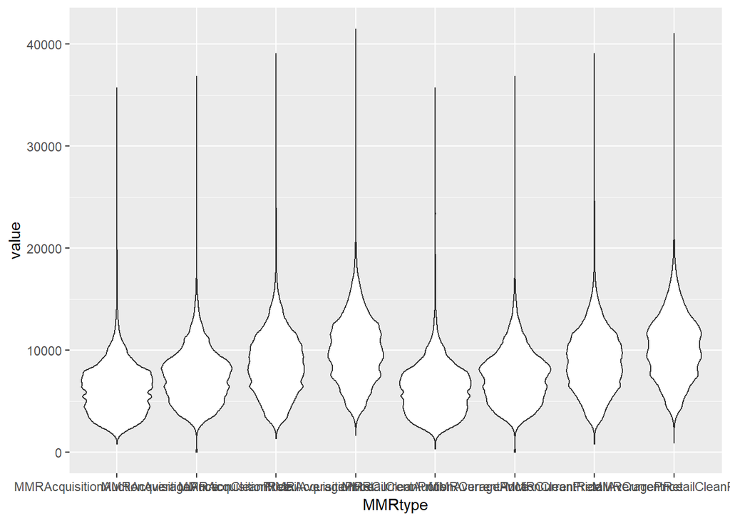

```r
g <- data.set[,grep("MMR", names(data.set))]
g <- gather(g, key = "MMRtype")
p <- ggplot(data = g, aes(x= MMRtype, y = value)) + geom_violin()
suppressWarnings(plot(p))
```

```r
rm(g)
```

#### Notating historical pricing errors for data imputation

Vehicle pricing data can be incorrect or incomplete. While vehicle value changes over time, certain tenets always hold true. For example, ‘Clean’ vehicles are always worth more than ‘Average’ cars and ‘Auction’ values are always lower than ‘Retail’ values. Identifying values that do not follow these basic tenets and setting them to NA for imputation purposes.

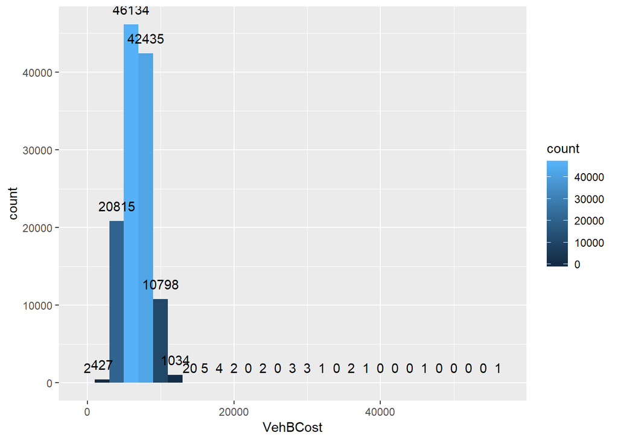

```r
data.set$MMRAcquisitionAuctionCleanPrice[data.set$MMRAcquisitionAuctionCleanPrice <= min(data.set$MMRAcquisitionAuctionAveragePrice, na.rm = TRUE)] <- NA
data.set$MMRCurrentAuctionCleanPrice[data.set$MMRCurrentAuctionCleanPrice <= min(data.set$MMRCurrentAuctionAveragePrice, na.rm = TRUE)] <- NA

p <- ggplot(data = data.set, aes(x = VehBCost)) + geom_histogram(binwidth = 2000, aes(fill = ..count..))
p <- p + stat_bin(binwidth = 2000, geom = "text", aes(label = ..count..), vjust = -1)
plot(p)
```

```r
range(data.set$VehBCost)
```

```
## [1]     1 56950
```

```r
data.set$VehBCost[data.set$VehBCost == 1] <- NA
```

#### Visualizing missing data

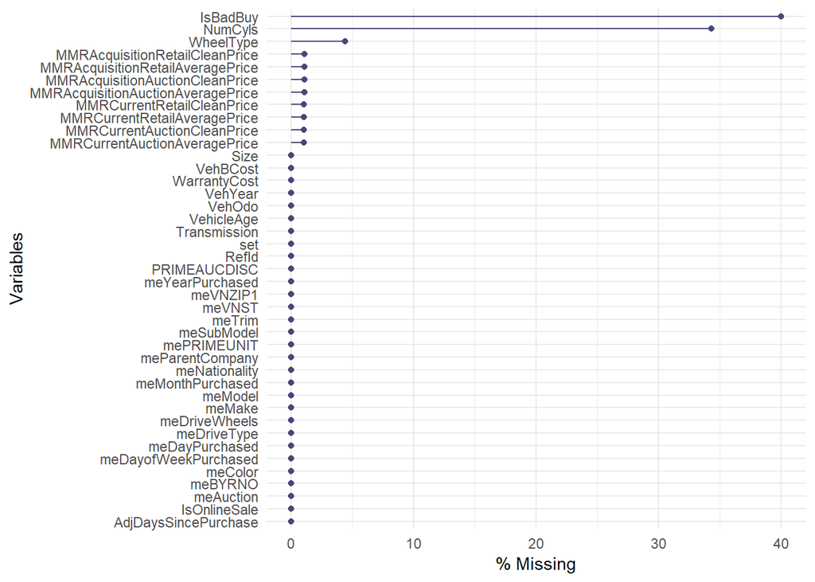

```r
gg_miss_var(data.set, show_pct = TRUE)
```

#### Creating function that returns the mode of a list of numbers

```r
mode <- function(array) {
        t <- as.data.frame(table(array))
        t <- t[order(t$Freq, decreasing = TRUE),]
        m <- head(t$array, 1)
        return(m)
}
```

#### Data Imputation

The imputation process has been divided up into multiple stages since imputation of certain fields could likely benefit from data in fields that also require imputed data to be complete. Furthermore, in an attempt to minimize processing time, only a handful of relevant fields have been chosen to use for imputation calculations. For example, the ZIP code in which a car is purchased is highly unlikely to have any predicting influence on the number of cyclinders the car has and can therefore be discarded for imputation purposes.

Imputing NumCyls field

```r
sub.data.numcyls <- select(data.set, VehYear, meTrim, meSubModel, meModel, meMake, NumCyls)
impute.data <- mice(sub.data.numcyls, m = 7, maxit = 5)
data.set$NumCyls[is.na(data.set$NumCyls)] <- apply(impute.data$imp$NumCyls, 1, mode)
rm(sub.data.numcyls);rm(impute.data)
```

Imputing WheelType field

```r
sub.data.wheels <- select(data.set, VehYear, meTrim, meSubModel, meModel, meMake, NumCyls, WheelType)
impute.data <- mice(sub.data.wheels, m = 7, maxit = 5)
data.set$WheelType[is.na(data.set$WheelType)] <- apply(impute.data$imp$WheelType, 1, mode)
rm(sub.data.wheels);rm(impute.data)
```

Imputing Historical Pricing fields

```r
sub.data.MMR <- select(data.set, VehYear, meTrim, meSubModel, meModel, meMake, NumCyls, WheelType, WarrantyCost, AdjDaysSincePurchase,
                       MMRAcquisitionAuctionAveragePrice, MMRAcquisitionAuctionCleanPrice, MMRAcquisitionRetailAveragePrice,
                       MMRAcquisitionRetailCleanPrice, MMRCurrentAuctionAveragePrice, MMRCurrentAuctionCleanPrice,
                       MMRCurrentRetailAveragePrice, MMRCurrentRetailCleanPrice)
impute.data <- mice(sub.data.MMR, m = 7, maxit = 5, method = "cart")
data.set$MMRAcquisitionAuctionAveragePrice[is.na(data.set$MMRAcquisitionAuctionAveragePrice)] <-
      apply(impute.data$imp$MMRAcquisitionAuctionAveragePrice, 1, mean)
data.set$MMRAcquisitionAuctionCleanPrice[is.na(data.set$MMRAcquisitionAuctionCleanPrice)] <-
      apply(impute.data$imp$MMRAcquisitionAuctionCleanPrice, 1, mean)
data.set$MMRAcquisitionRetailAveragePrice[is.na(data.set$MMRAcquisitionRetailAveragePrice)] <-
      apply(impute.data$imp$MMRAcquisitionRetailAveragePrice, 1, mean)
data.set$MMRAcquisitionRetailCleanPrice[is.na(data.set$MMRAcquisitionRetailCleanPrice)] <-
      apply(impute.data$imp$MMRAcquisitionRetailCleanPrice, 1, mean)
data.set$MMRCurrentAuctionAveragePrice[is.na(data.set$MMRCurrentAuctionAveragePrice)] <-
      apply(impute.data$imp$MMRCurrentAuctionAveragePrice, 1, mean)
data.set$MMRCurrentAuctionCleanPrice[is.na(data.set$MMRCurrentAuctionCleanPrice)] <-
      apply(impute.data$imp$MMRCurrentAuctionCleanPrice, 1, mean)
data.set$MMRCurrentRetailAveragePrice[is.na(data.set$MMRCurrentRetailAveragePrice)] <- apply(impute.data$imp$MMRCurrentRetailAveragePrice, 1, mean)
data.set$MMRCurrentRetailCleanPrice[is.na(data.set$MMRCurrentRetailCleanPrice)] <-
      apply(impute.data$imp$MMRCurrentRetailCleanPrice, 1, mean)
rm(sub.data.MMR);rm(impute.data)
```

Imputing Vehicle Size field

```r
sub.data.size <- select(data.set, meTrim, meModel, meMake, Size)
impute.data <- mice(sub.data.size, m = 7, maxit = 5, method = "cart")
data.set$Size[is.na(data.set$Size)] <- apply(impute.data$imp$Size, 1, mode)
rm(sub.data.size);rm(impute.data)
```

Imputing Vehicle Cost field

```r
sub.data.cost <- select(data.set, meModel, meMake, VehYear, VehBCost)
impute.data <- mice(sub.data.cost, m = 7, maxit = 5)
data.set$VehBCost[is.na(data.set$VehBCost)] <- apply(impute.data$imp$VehBCost, 1, mean)
rm(sub.data.cost);rm(impute.data)
```

#### Performing Means Encoding on newly imputed fields

```r
data.set <- data.set %>% mutate(meSize = means_encoding(data.set, "Size", "IsBadBuy"),
                                meNumCyls = means_encoding(data.set, "NumCyls", "IsBadBuy"),
                                meWheelType = means_encoding(data.set, "WheelType", "IsBadBuy")) %>%
                         select(-NumCyls, -Size, -WheelType)
```

#### Manually imputing illogical historical pricing values

Some historical pricing values are inaccurate and/or illogical. Retail values should always be higher than Auction values, ‘Clean’ cars should always be of equal or higher value than ‘Average’ cars. These illogical values will be replaced with adjusted average values.

```r
MMRmean <- as.data.frame(apply(data.set[,grep("MMR", names(data.set))], 2, mean))
names(MMRmean) <- c("average")
data.set$MMRAcquisitionAuctionCleanPrice[data.set$MMRAcquisitionAuctionCleanPrice < data.set$MMRAcquisitionAuctionAveragePrice] <-
        data.set$MMRAcquisitionAuctionCleanPrice[data.set$MMRAcquisitionAuctionCleanPrice < data.set$MMRAcquisitionAuctionAveragePrice] * MMRmean$average[2]/MMRmean$average[1]
data.set$MMRAcquisitionRetailAveragePrice[data.set$MMRAcquisitionRetailAveragePrice < data.set$MMRAcquisitionAuctionAveragePrice] <-
        data.set$MMRAcquisitionRetailAveragePrice[data.set$MMRAcquisitionRetailAveragePrice < data.set$MMRAcquisitionAuctionAveragePrice] *
        MMRmean$average[3]/MMRmean$average[1]
data.set$MMRAcquisitionRetailCleanPrice[data.set$MMRAcquisitionRetailCleanPrice < data.set$MMRAcquisitionRetailAveragePrice] <-
        data.set$MMRAcquisitionRetailCleanPrice[data.set$MMRAcquisitionRetailCleanPrice < data.set$MMRAcquisitionRetailAveragePrice] *
        MMRmean$average[4]/MMRmean$average[3]
data.set$MMRCurrentAuctionCleanPrice[data.set$MMRCurrentAuctionCleanPrice < data.set$MMRCurrentAuctionAveragePrice] <-
        data.set$MMRCurrentAuctionCleanPrice[data.set$MMRCurrentAuctionCleanPrice < data.set$MMRCurrentAuctionAveragePrice] *
        MMRmean$average[6]/MMRmean$average[5]
data.set$MMRCurrentRetailAveragePrice[data.set$MMRCurrentRetailAveragePrice < data.set$MMRCurrentAuctionAveragePrice] <-
        data.set$MMRCurrentRetailAveragePrice[data.set$MMRCurrentRetailAveragePrice < data.set$MMRCurrentAuctionAveragePrice] *
        MMRmean$average[7]/MMRmean$average[5]
data.set$MMRCurrentRetailCleanPrice[data.set$MMRCurrentRetailCleanPrice < data.set$MMRCurrentRetailAveragePrice] <-
        data.set$MMRCurrentRetailCleanPrice[data.set$MMRCurrentRetailCleanPrice < data.set$MMRCurrentRetailAveragePrice] *
        MMRmean$average[8]/MMRmean$average[7]
```

#### Generating additional Features

Historical pricing differences can give insight into profits/losses of vehicle models. Additionally, warranty costs are an indicator of typical repair costs that vehicles typically see. Various ratios involving mileage, cost, age, etc are also solid indicators of a vehicle’s overall condition.

```r
data.set <- data.set %>% mutate(AARA = MMRAcquisitionAuctionCleanPrice - MMRAcquisitionAuctionAveragePrice,
                                ARCA = MMRAcquisitionRetailCleanPrice - MMRAcquisitionRetailAveragePrice,
                                CACA = MMRCurrentAuctionCleanPrice - MMRCurrentAuctionAveragePrice,
                                CRCA = MMRCurrentRetailCleanPrice - MMRCurrentRetailAveragePrice,
                                ARAA = MMRAcquisitionRetailAveragePrice - MMRAcquisitionAuctionAveragePrice,
                                ARAC = MMRAcquisitionRetailCleanPrice - MMRAcquisitionAuctionCleanPrice,
                                CRAA = MMRCurrentRetailAveragePrice - MMRCurrentAuctionAveragePrice,
                                CRAC = MMRCurrentRetailCleanPrice - MMRCurrentAuctionCleanPrice,
                                mpy = VehOdo/(VehicleAge + 1),
                                cpy = VehBCost/(VehicleAge + 1),
                                cpm = VehBCost/VehOdo,
                                wpc = WarrantyCost/VehBCost,
                                VehYear = as.numeric(VehYear),
                                VehicleAge = as.numeric(VehicleAge),
                                VehOdo = as.numeric(VehOdo),
                                IsOnlineSale = as.numeric(IsOnlineSale),
                                WarrantyCost = as.numeric(WarrantyCost))
```

#### Removing highly correlated fields

```r
nn <- select(data.set, IsBadBuy, set)
data.set <- select(data.set, -IsBadBuy, -set)
correlation <- cor(data.set)
fc <- findCorrelation(correlation, cutoff = 0.98)
data.set <- as.data.frame(cbind(nn, data.set[,-fc]))
rm(nn)
```

#### Removing extraneous characters from field names

```r
names(data.set)[grep("=| ", names(data.set))] <- gsub("=| ", "", names(data.set)[grep("=", names(data.set))])
```

#### Reserving IDs for later use

```r
test.ID <- data.set$RefId[data.set$set == "test"]
```

#### Scaling numerical data

```r
to.be.scaled <- grep("VehYear|VehicleAge|VehOdo|MMR.*|VehBCost|WarrantyCost|YearPurchased|MonthPurchased|DayPurchase|YearDiscrepancy|AdjDaysSincePurchase|AARA|ARCA|CACA|CRCA|ARAC|CRAC|mpy|cpy",
                     names(data.set))
data.set[,to.be.scaled] <- sapply(to.be.scaled, function(x) scale(data.set[,x]))
```

#### Splitting data back into train and test sets

```r
training.set <- data.set %>% filter(set == "train") %>%
                             select(-set, -RefId)
test.set <- data.set %>% filter(set == "test") %>%
                         select(-IsBadBuy, -set, -RefId)
```

#### Converting response variable to factor

```r
training.set$IsBadBuy <- as.factor(training.set$IsBadBuy)
```

#### Examining class balance of response

```r
table(training.set$IsBadBuy)
```

```
##
##     0     1
## 64007  8976
```

```r
training.set <- SMOTE(IsBadBuy~., data = training.set, perc.over = 315, perc.under = 115, k = 4)
table(training.set$IsBadBuy)
```

```
##
##     0     1
## 30967 35904
```

### Model Generation

The final model will be an ensemble of 3 distinct models that will be trained below. Once each of the 3 models is trained, their results will be aggregated into a data frame and a final model will be trained on those figures. The reason behind this is twofold: 1) no model is perfect, so an aggregate of several models will help to smooth out the errors of any one particular model and 2) some models are invariably better at picking up on certain nuances in the data structure than others, so the idea is to feed mulitple model results into a final model in order to identify when certain models are more accurate.

Because various modeling functions require the data to be formatted in different ways, the original training set will remain unmodified and subsections below for each individual model will reformat the data in such as way that the corresponding modeling function can use.

#### Creating RandomForest model

```r
intrain <- createDataPartition(training.set$IsBadBuy, p = 0.7, list = FALSE)
val.set <- training.set[-intrain,]
train.set <- training.set[intrain,]

rf <- randomForest(IsBadBuy~.,
                   data = train.set,
                   ntree = 1000,
                   importance = TRUE,
                   keep.forest = TRUE)
```

#### RandomForest predictions

```r
rf.predict <- predict(rf, select(val.set, -IsBadBuy))
confusionMatrix(as.factor(rf.predict), as.factor(val.set$IsBadBuy))
```

```
## Confusion Matrix and Statistics
##
##           Reference
## Prediction    0    1
##          0 9097 2411
##          1  193 8360
##
##                Accuracy : 0.8702
##                  95% CI : (0.8655, 0.8748)
##     No Information Rate : 0.5369
##     P-Value [Acc > NIR] : < 2.2e-16
##
##                   Kappa : 0.7432
##  Mcnemar's Test P-Value : < 2.2e-16
##
##             Sensitivity : 0.9792
##             Specificity : 0.7762
##          Pos Pred Value : 0.7905
##          Neg Pred Value : 0.9774
##              Prevalence : 0.4631
##          Detection Rate : 0.4535
##    Detection Prevalence : 0.5737
##       Balanced Accuracy : 0.8777
##
##        'Positive' Class : 0
##
```

#### Creating Gradient Boosted Tree Model

```r
intrain <- createDataPartition(training.set$IsBadBuy, p = 0.7, list = FALSE)
val.set <- training.set[-intrain,]
train.set <- training.set[intrain,]
train.y <- as.matrix(train.set$IsBadBuy)
train.x <- as.matrix(select(train.set, -IsBadBuy))
val.y <- as.matrix(val.set$IsBadBuy)
val.x <- as.matrix(select(val.set, -IsBadBuy))

tg <- list(max_depth = 5,
           eta = 0.01,
           gamma = 0,
           colsample_bytree = 1,
           min_child_weight = 0.5,
           subsample = 1,
           num_class = 2,
           eval_metric = "mlogloss",
           objective = "multi:softprob")

gb <- xgboost(data = train.x,
              label = train.y,
              params = tg,
              nrounds = 7000,
              verbose = 1,
              print_every_n = 500)
```

#### Gradient Boosted Tree Predictions

The prediction function outputs probabilities rather than class predictions. Probabilities will be used in the final model, but for a summary of the results, the probabilities are converted to predictions.

```r
gb.predict <- predict(gb, val.x)
gb.predict <- as.data.frame(matrix(data = gb.predict, nrow = 0.5*length(gb.predict), ncol = 2, byrow = TRUE))
names(gb.predict) <- c("zero", "one")
gb.predict$class <- ifelse(gb.predict$one >= gb.predict$zero, 1, 0)
confusionMatrix(as.factor(gb.predict$class), as.factor(val.y))
```

```
## Confusion Matrix and Statistics
##
##           Reference
## Prediction    0    1
##          0 8957 2135
##          1  333 8636
##
##                Accuracy : 0.877
##                  95% CI : (0.8724, 0.8815)
##     No Information Rate : 0.5369
##     P-Value [Acc > NIR] : < 2.2e-16
##
##                   Kappa : 0.7559
##  Mcnemar's Test P-Value : < 2.2e-16
##
##             Sensitivity : 0.9642
##             Specificity : 0.8018
##          Pos Pred Value : 0.8075
##          Neg Pred Value : 0.9629
##              Prevalence : 0.4631
##          Detection Rate : 0.4465
##    Detection Prevalence : 0.5529
##       Balanced Accuracy : 0.8830
##
##        'Positive' Class : 0
##
```

#### Creating AdaBoost model

```r
intrain <- createDataPartition(training.set$IsBadBuy, p = 0.7, list = FALSE)
val.set <- training.set[-intrain,]
train.set <- training.set[intrain,]
train.y <- as.matrix(as.numeric(train.set$IsBadBuy) - 1)
train.y <- ifelse(train.y == 1, 1, -1)
train.x <- as.matrix(select(train.set, -IsBadBuy))
val.y <- as.matrix(val.set$IsBadBuy)
val.x <- as.matrix(select(val.set, -IsBadBuy))

ab <- adaboost(X = train.x, y = train.y, tree_depth = 5, n_rounds = 1500)
```

#### Adaboost Predictions

```r
ab.predict <- predict(ab, val.x)
ab.p <- ifelse(ab.predict == 1, 1, 0)
confusionMatrix(as.factor(val.y), as.factor(ab.p))
```

```
## Confusion Matrix and Statistics
##
##           Reference
## Prediction    0    1
##          0 8768  522
##          1 2071 8700
##
##                Accuracy : 0.8707
##                  95% CI : (0.866, 0.8754)
##     No Information Rate : 0.5403
##     P-Value [Acc > NIR] : < 2.2e-16
##
##                   Kappa : 0.743
##  Mcnemar's Test P-Value : < 2.2e-16
##
##             Sensitivity : 0.8089
##             Specificity : 0.9434
##          Pos Pred Value : 0.9438
##          Neg Pred Value : 0.8077
##              Prevalence : 0.5403
##          Detection Rate : 0.4371
##    Detection Prevalence : 0.4631
##       Balanced Accuracy : 0.8762
##
##        'Positive' Class : 0
##
```

#### Compiling predictions of various models and validation outcomes

```r
ens <- data.frame(boosted = gb.predict$one,
                  randomforest = as.numeric(rf.predict),
                  ada = ab.predict,
                  result = as.factor(val.y))
```

### Generating final ensemble model and predictions for submission

#### Creating Random Forest ensemble model

```r
rf.ens <- randomForest(result~.,
                       data = ens,
                       ntree = 250,
                       keep.forest = TRUE)
```

#### Generating test results based on test set predictions and ensemble model

```r
final.gbm.predict <- predict(gb, as.matrix(test.set))
final.rf.predict <- predict(rf, test.set)
final.ada.predict <- predict(ab, as.matrix(test.set))
final.gbm.predict <- as.data.frame(matrix(data = final.gbm.predict, nrow = 0.5*length(final.gbm.predict), ncol = 2, byrow = TRUE))
names(final.gbm.predict) <- c("zero", "one")
final.gbm.predict <- final.gbm.predict$one
```

#### Final Predictions dataframe

```r
edf <- data.frame(boosted = final.gbm.predict,
                  randomforest = as.numeric(final.rf.predict),
                  ada = final.ada.predict)
```

#### Generating final ensemble predictions and writing to csv

```r
final <- predict(rf.ens, edf)
final <- as.data.frame(cbind(test.ID, final))
names(final) <- c("RefId", "IsBadBuy")
final$IsBadBuy <- final$IsBadBuy - 1
write.csv(final, paste(wd, "finalguess.csv"), row.names = FALSE)
```